# DN1 Anja Trobec

Nas primer:

```r
n <- 26
```

Nasi podatki (oznacimo s $k$ realizacijo $X$ na nasem vzorcu):

```r
k <- 6
```

1. NALOGA

Preizkusite razlicne informativne apriorne beta porazdelitve za primer, ki smo ga imeli na prvi vaji.

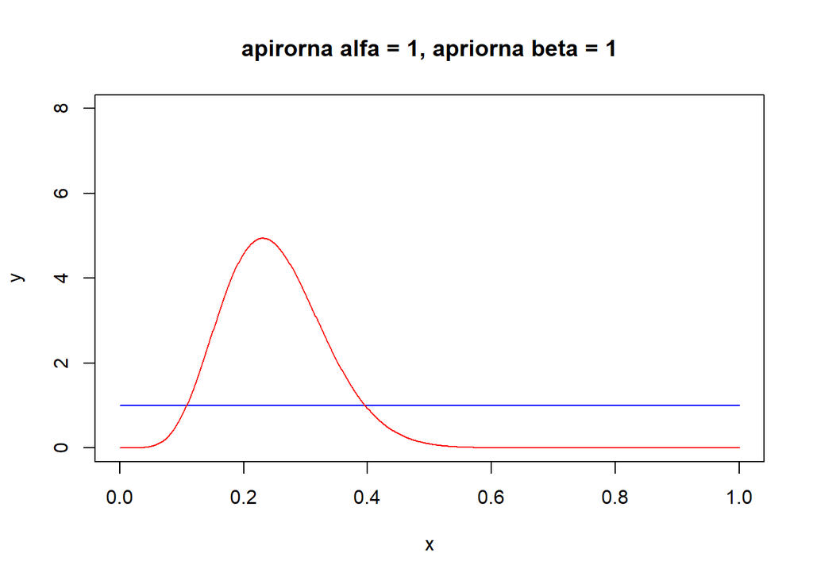

```r
#PRVA VAJA


alfa <- 1
beta <- 1

x <- seq(0, 1, 0.001)

risi_apriorna <- function(a,b) {
  y <- dbeta(x, a, b)
  title <- paste("apirorna alfa = " , as.character(a),", ", "apriorna beta = ", as.character(b), sep = "")
  plot(x, y, type='l', col='blue', ylim=c(0,8), main = title)
}

risi_aposteriorna <- function(a,b) {
  a_ap <- a + k
  b_ap <- b + n - k
  aposteriorna <- dbeta(x, a_ap, b_ap)
  lines(x, aposteriorna, type='l', col='red', ylim=c(0,8))
}

risi_apriorna(alfa,beta)
risi_aposteriorna(alfa,beta)
```

```r
vrh <- round((alfa+k)/(alfa+beta+n),2)

komentar <- paste("Pri alfa = 1 in beta = 1 imamo enakomerno zvezno apriorno gostoto. Aposteriorna gostota, pa ima vrh pri ", as.character(vrh), ".",sep="")
print(komentar)
```

```
## [1] "Pri alfa = 1 in beta = 1 imamo enakomerno zvezno apriorno gostoto. Aposteriorna gostota, pa ima vrh pri 0.25."
```

Pri spreminjanju $\alpha$ in $\beta$ poskusite razlicne kombinacije glede na to, ali sta (oba) parametra vecja oziroma manjsa od 1. Kaj se zgodi, ce ju zamenjamo? Kaj se zgodi, ce oba povecamo? Pri vsaki razlicici apriorne porazdelitve narisite graf, na katerem sta narisani apriorna in aposteriorna porazdelitev. Povzemite obnasanje apriorne in aposteriorne porazdelitve v nekaj stavkih.

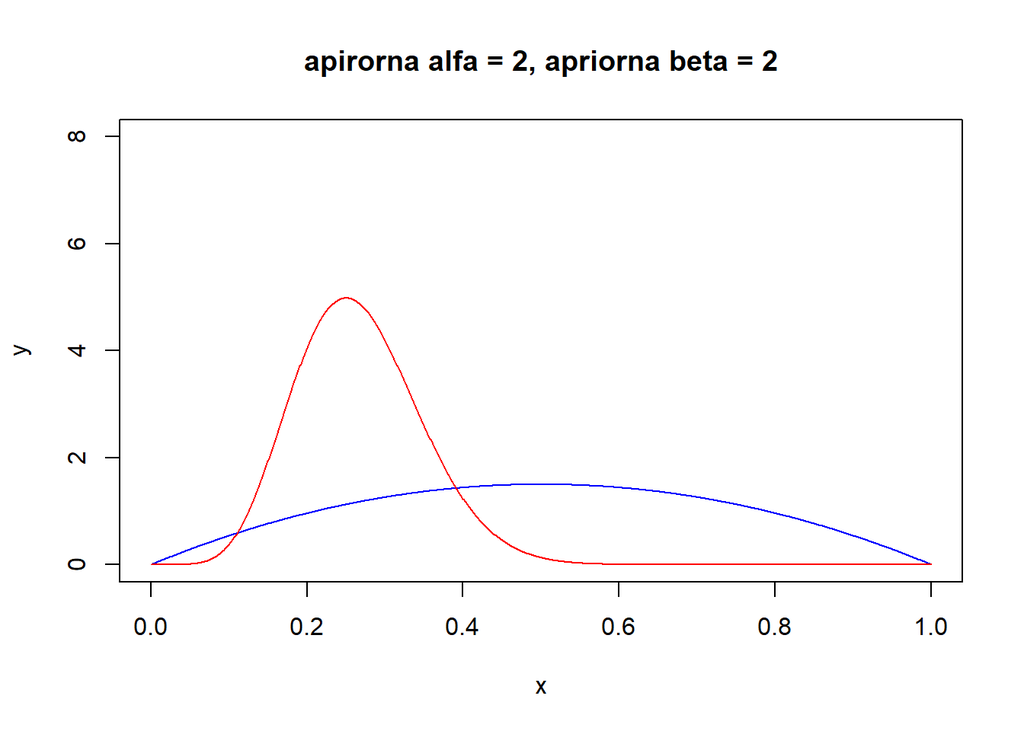

```r
# alfa > 1 in beta > 1

alfa <- 2
beta <- 2

risi_apriorna(alfa,beta)
risi_aposteriorna(alfa,beta)
```

```r
vrh <- round((alfa+k)/(alfa+beta+n),2)

komentar <- paste("Ce sta oba parametra - alfa in beta - strogo vecja od 1, gre za unimodalno apriorno porazdelitev, ki ima konkavno obliko. Aposteriorna porazdelitev ohrani enako obliko kot zgoraj z vrhom v ", as.character(vrh), ".",sep="" )
print(komentar)
```

```
## [1] "Ce sta oba parametra - alfa in beta - strogo vecja od 1, gre za unimodalno apriorno porazdelitev, ki ima konkavno obliko. Aposteriorna porazdelitev ohrani enako obliko kot zgoraj z vrhom v 0.27."
```

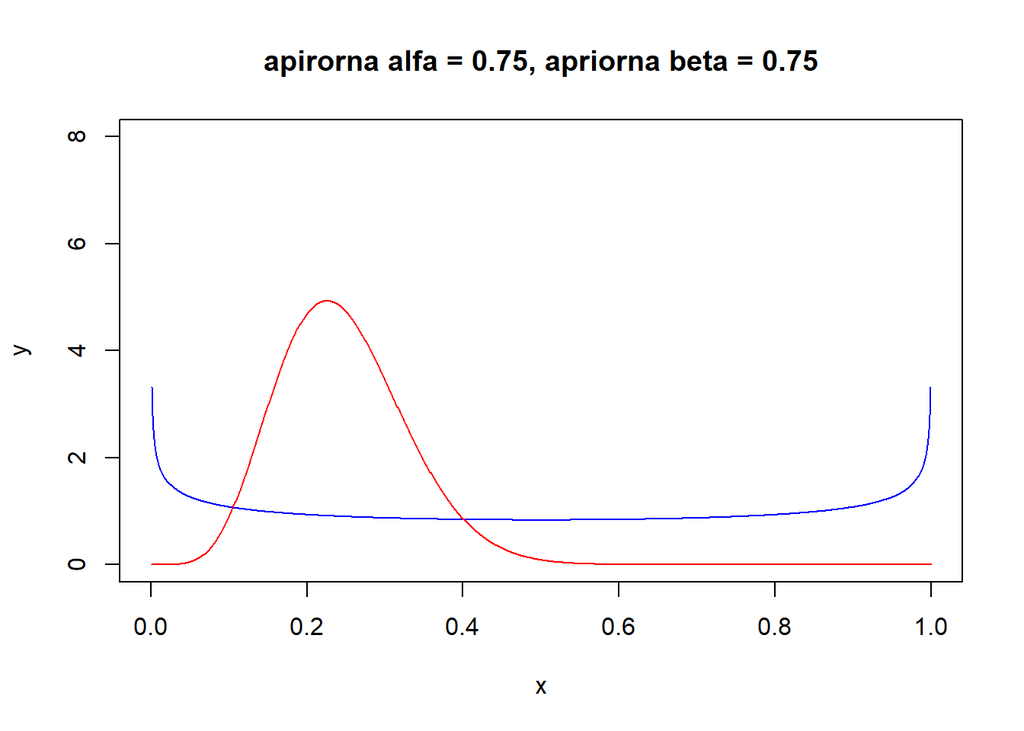

```r
# alfa < 1 in beta < 1
alfa <- 0.75
beta <- 0.75


risi_apriorna(alfa,beta)
risi_aposteriorna(alfa,beta)
```

```r
vrh <- round((alfa+k)/(alfa+beta+n),2)

komentar <- paste("Gostota apriorne porazdelitve za alfa in beta strogo manjsa od 1 ima obliko crke U in je konveksna. Aposteriorna porazdelitev ohrani enako obliko kot zgoraj z vrhom v ", as.character(vrh), ".",sep="")
print(komentar)
```

```
## [1] "Gostota apriorne porazdelitve za alfa in beta strogo manjsa od 1 ima obliko crke U in je konveksna. Aposteriorna porazdelitev ohrani enako obliko kot zgoraj z vrhom v 0.25."
```

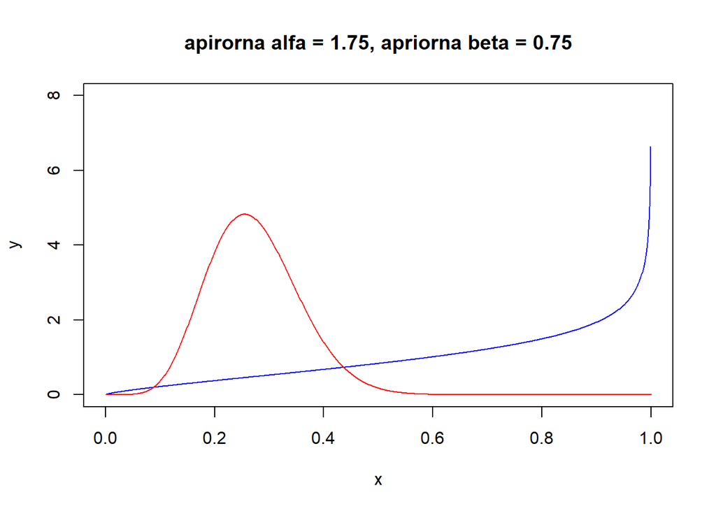

```r
# alfa > 1 in beta < 1

alfa <- 1.75
beta <- 0.75


risi_apriorna(alfa,beta)
risi_aposteriorna(alfa,beta)
```

```r
vrh <- round((alfa+k)/(alfa+beta+n),2)

komentar <- paste("Kadar je alfa > 1 in beta < 1 dobimo narascajoco funkcijo apriorne gostote. Aposteriorna porazdelitev ohrani enako obliko kot zgoraj z vrhom v ", as.character(vrh), ".",sep="")
print(komentar)
```

```
## [1] "Kadar je alfa > 1 in beta < 1 dobimo narascajoco funkcijo apriorne gostote. Aposteriorna porazdelitev ohrani enako obliko kot zgoraj z vrhom v 0.27."
```

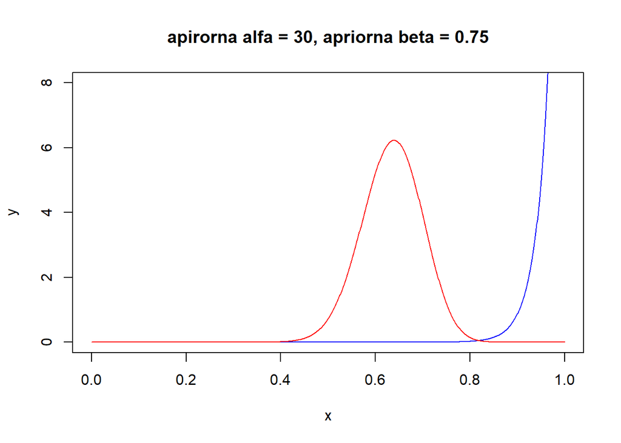

```r
# alfa >> 1 in beta < 1

alfa <- 30
beta <- 0.75


risi_apriorna(alfa,beta)
risi_aposteriorna(alfa,beta)
```

```r
vrh <- round((alfa+k)/(alfa+beta+n),2)

komentar <- paste("Kadar je alfa >> 1 in beta < 1 dobimo narascajoco funkcijo apriorne gostote. Za velike alfe tako dobimo robno porazdelitev pri x = 1. Aposteriorna porazdelitev ohrani enako obliko kot zgoraj z vrhom v ", as.character(vrh), ".",sep="")
print(komentar)
```

```
## [1] "Kadar je alfa >> 1 in beta < 1 dobimo narascajoco funkcijo apriorne gostote. Za velike alfe tako dobimo robno porazdelitev pri x = 1. Aposteriorna porazdelitev ohrani enako obliko kot zgoraj z vrhom v 0.63."
```

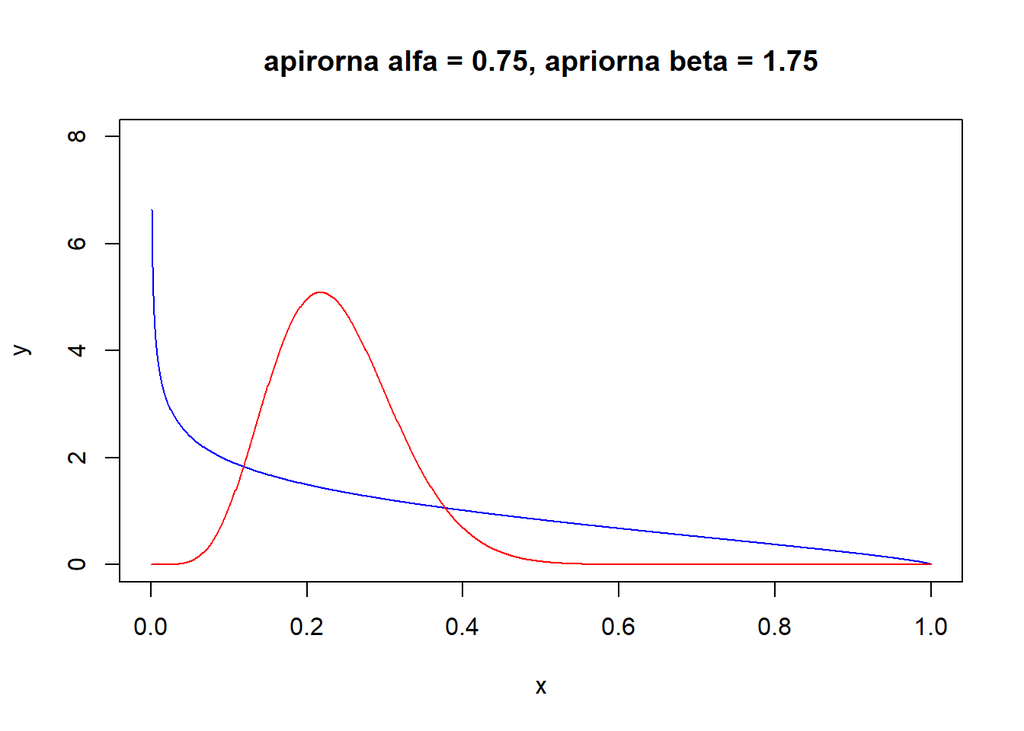

```r
# alfa < 1 in beta > 1
alfa <- 0.75
beta <- 1.75

risi_apriorna(alfa,beta)
risi_aposteriorna(alfa,beta)
```